# Differential Gene Expression of CFW vs YPD in WT at 37°C

Rachael Murray

2024-12-19

# Summary

Differential Gene Expression +CFW vs -CFW in WT at 37°C samples, using DESeq2

This analysis produces files:

- `deseq_df_CFWvsYPD_WT_37C.txt`
- `deglist_CFWvsYPD_WT_37C_up2x_FDR5.txt`
- `deglist_CFWvsYPD_WT_37C_down2x_FDR5.txt`

## Load count data from shared script load_count_data.Rmd

# Load and organise count data

`load_count_data.Rmd` is just to load and organise the raw count data in R, as well as loading libraries for data analysis. Other scripts can just run this one instead of duplicating code, especially scripts for differential gene expression analysis.

This runs *after* `QC_PCA.Rmd`, which does the organisation. This just loads the organised counts from the file `results/summaries/counts_bysamplecode.txt`.

## Load the organised counts

```r
counts_all <-
  here::here("results", "summaries", "counts_bysamplecode.txt") %>%
  readr::read_tsv(comment = "#",
                  col_types = "ciiiiiiiiiiiiiiiiiiiiiiiiiiiiiii")   %>%
  magrittr::set_rownames(.$Gene)
counts_all
```

```
## # A tibble: 6,795 × 32
##    Gene       Length WT_30_Y_1 WT_30_Y_2 WT_30_Y_3 FL_30_Y_1 FL_30_Y_2 FL_30_Y_3
##  * <chr>       <int>     <int>     <int>     <int>     <int>     <int>     <int>
##  1 CNAG_00002   1027       322       378       346       310       309       174
##  2 CNAG_00003   2397        19        43        27        54        52        33
##  3 CNAG_00004   3424        94        80        83       102        94        65
##  4 CNAG_00005   2162       462       399       385       378       344       310
##  5 CNAG_00006   1450      1019      1533      1256      1505      1359       778
##  6 CNAG_00007   2294       471       703       579       476       407       284
##  7 CNAG_00008   4351       141       226       206       272       259       164
##  8 CNAG_00009   1794       160       162       187       323       250       171
##  9 CNAG_00010   3879       195       199       242       362       272       159
## 10 CNAG_00011   2037        85       117       114       162       139        81
## # ℹ 6,785 more rows
## # ℹ 24 more variables: WT_37_Y_1 <int>, WT_37_Y_2 <int>, WT_37_Y_3 <int>,
## #   FL_37_Y_1 <int>, FL_37_Y_2 <int>, FL_37_Y_3 <int>, WT_37_C_1 <int>,
## #   WT_37_C_2 <int>, WT_37_C_3 <int>, FL_37_C_1 <int>, FL_37_C_2 <int>,
## #   FL_37_C_3 <int>, WT_37_E_1 <int>, WT_37_E_2 <int>, WT_37_E_3 <int>,
## #   FL_37_E_1 <int>, FL_37_E_2 <int>, FL_37_E_3 <int>, WT_37_CE_1 <int>,
## #   WT_37_CE_2 <int>, WT_37_CE_3 <int>, FL_37_CE_1 <int>, FL_37_CE_2 <int>, …
```

## Load the sample sheet

```r
sample_sheet <-
  here::here("input", "experiment",
             "CryptoRNAseqFLC1SampleKey.csv") %>%
  readr::read_csv(comment = "#", col_types = "ccccccc") %>%
  dplyr::mutate(Condition = stringr::str_sub(SampleName,start = 1L, end = -3L)) %>%
  dplyr::transmute(SampleID = as_factor(SampleID),
                   SampleName = as_factor(SampleName),
                   Condition = as_factor(Condition),
                   FLC1 = factor(FLC1, levels = c("delta", "WT")),
                   Temperature = factor(Temperature, levels = c("30", "37")),
                   Media = as_factor(Media),
                   BioRep = as_factor(BioRep))

sample_sheet
```

```
## # A tibble: 30 × 7
##    SampleID SampleName Condition FLC1  Temperature Media BioRep
##    <fct>    <fct>      <fct>     <fct> <fct>       <fct> <fct>
##  1 1        WT_30_Y_1  WT_30_Y   WT    30          YPD   1
##  2 2        WT_30_Y_2  WT_30_Y   WT    30          YPD   2
##  3 3        WT_30_Y_3  WT_30_Y   WT    30          YPD   3
##  4 4        FL_30_Y_1  FL_30_Y   delta 30          YPD   1
##  5 5        FL_30_Y_2  FL_30_Y   delta 30          YPD   2
##  6 6        FL_30_Y_3  FL_30_Y   delta 30          YPD   3
##  7 7        WT_37_Y_1  WT_37_Y   WT    37          YPD   1
##  8 8        WT_37_Y_2  WT_37_Y   WT    37          YPD   2
##  9 9        WT_37_Y_3  WT_37_Y   WT    37          YPD   3
## 10 10       FL_37_Y_1  FL_37_Y   delta 37          YPD   1
## # ℹ 20 more rows
```

## Load H99 Gene information

```r
gene_info_df <-
  here::here("input", "annotation",
             "H99_geneinfo_FungiDB59.txt") %>%
  readr::read_tsv(comment = "#")  %>%
  dplyr::rename(gene = GeneID, geneName = GeneName)
```

# DESeq on a subset of data, only WT in CFW and YPD at 37C

```r
sample_sheet_CFWvsYPD_WT_37C <-
  dplyr::filter(sample_sheet,
                FLC1 == "WT",
                Media %in% c("YPD", "YPD_CFW"),
                Temperature == "37"
  )

dds_CFWvsYPD_WT_37C <-
  DESeqDataSetFromMatrix(
    countData = counts_all %>%
      dplyr::select(sample_sheet_CFWvsYPD_WT_37C$SampleName) %>%
      magrittr::set_rownames(counts_all$Gene),
    colData = sample_sheet_CFWvsYPD_WT_37C,
    design = ~ Media) %>%
  DESeq()
```

```
## factor levels were dropped which had no samples
```

```r
dds_CFWvsYPD_WT_37C
```

```
## class: DESeqDataSet
## dim: 6795 6
## metadata(1): version
## assays(4): counts mu H cooks
## rownames(6795): CNAG_00002 CNAG_00003 ... CNAG_14001 CNAG_14002
## rowData names(22): baseMean baseVar ... deviance maxCooks
## colnames(6): WT_37_Y_1 WT_37_Y_2 ... WT_37_C_2 WT_37_C_3
## colData names(8): SampleID SampleName ... BioRep sizeFactor
```

```r
results(dds_CFWvsYPD_WT_37C)
```

```
## log2 fold change (MLE): Media YPD CFW vs YPD
## Wald test p-value: Media YPD CFW vs YPD
## DataFrame with 6795 rows and 6 columns
##             baseMean log2FoldChange     lfcSE       stat    pvalue      padj
##            <numeric>      <numeric> <numeric>  <numeric> <numeric> <numeric>
## CNAG_00002  369.3402      0.0673854 0.1463731  0.4603676  0.645252  0.857604
## CNAG_00003   30.4386     -0.3069897 0.3384124 -0.9071466  0.364329        NA
## CNAG_00004   94.5621     -0.0123738 0.2044561 -0.0605207  0.951741        NA
## CNAG_00005  549.9990      0.0559102 0.1377793  0.4057957  0.684893  0.878417
## CNAG_00006 1414.0702     -0.0521715 0.0983831 -0.5302886  0.595912  0.831050
## ...              ...            ...       ...        ...       ...       ...
## CNAG_08027 240.18703     -0.0301358  0.148188  -0.203362 0.8388521  0.951375
## CNAG_08028  82.85411      0.0225573  0.211047   0.106883 0.9148821        NA
## CNAG_08029  80.42711     -0.4426523  0.215699  -2.052178 0.0401523        NA
## CNAG_14001 303.72097     -0.2746245  0.146246  -1.877830 0.0604044  0.307310
## CNAG_14002   1.33694      1.6937389  1.605748   1.054797 0.2915181        NA
```

```r
resultsNames(dds_CFWvsYPD_WT_37C)
```

```
## [1] "Intercept"            "Media_YPD_CFW_vs_YPD"
```

```r
deseq_df_CFWvsYPD_WT_37C <-
  biobroom::tidy.DESeqDataSet(dds_CFWvsYPD_WT_37C) %>%
  dplyr::filter(term == "Media_YPD_CFW_vs_YPD") %>%
  dplyr::left_join(gene_info_df,
                   by = "gene") %>%
  dplyr::select(gene,
                geneName,
                baseMean,
                log2FC = estimate,
                stderror,
                padj = p.adjusted)
```

## List DEGs most UP in CFW vs YPD in WT at 37°C

We cut off at 2x changes with 5% FDR here.

```r
# Make data frames of DEGs up and down, arranged by log2FC
DEGdf_CFW_up2x_FDR5 <-
  dplyr::filter(deseq_df_CFWvsYPD_WT_37C,
                log2FC > 1, padj < 0.05) %>%
  dplyr::arrange(desc(log2FC))
print(DEGdf_CFW_up2x_FDR5, n = 20)
```

```
## # A tibble: 3 × 6
##   gene       geneName baseMean log2FC stderror     padj
##   <chr>      <chr>       <dbl>  <dbl>    <dbl>    <dbl>
## 1 CNAG_00979 CTR4         412.   1.52   0.177  7.00e-15
## 2 CNAG_03223 <NA>        9067.   1.16   0.0981 1.61e-28
## 3 CNAG_02775 BIM1        1847.   1.08   0.0967 8.57e-26
```

Print the top 20 *named* DEGs

```r
DEGdf_CFW_up2x_FDR5 %>%
  dplyr::filter(!is.na(geneName)) %>%
  print(n = 20)
```

```
## # A tibble: 2 × 6
##   gene       geneName baseMean log2FC stderror     padj
##   <chr>      <chr>       <dbl>  <dbl>    <dbl>    <dbl>
## 1 CNAG_00979 CTR4         412.   1.52   0.177  7.00e-15
## 2 CNAG_02775 BIM1        1847.   1.08   0.0967 8.57e-26
```

## List DEGs most DOWN in CFW vs YPD in WT at 37°C

```r
# Make data frames of DEGs up and down, arranged by log2FC
DEGdf_CFW_down2x_FDR5 <-
  dplyr::filter(deseq_df_CFWvsYPD_WT_37C,
                log2FC < -1, padj < 0.05) %>%
  dplyr::arrange(log2FC)
print(DEGdf_CFW_down2x_FDR5, n = 20)
```

```
## # A tibble: 1 × 6
##   gene       geneName baseMean log2FC stderror       padj
##   <chr>      <chr>       <dbl>  <dbl>    <dbl>      <dbl>
## 1 CNAG_03850 SPT7         475.  -1.05    0.183 0.00000328
```

Print the top 20 *named* DEGs

```r
DEGdf_CFW_down2x_FDR5 %>%
  dplyr::filter(!is.na(geneName)) %>%
  print(n = 20)
```

```
## # A tibble: 1 × 6
##   gene       geneName baseMean log2FC stderror       padj
##   <chr>      <chr>       <dbl>  <dbl>    <dbl>      <dbl>
## 1 CNAG_03850 SPT7         475.  -1.05    0.183 0.00000328
```

## Volcano plot of DEGs

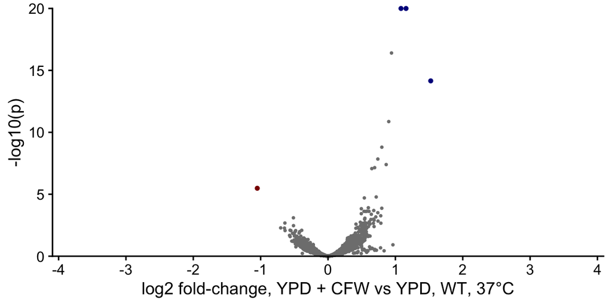

```r
volcano_CFWvsYPD_WT_37C <-
  ggplot(data = deseq_df_CFWvsYPD_WT_37C,
         aes(x = log2FC, y = -log10(padj)) ) +
  geom_point(size = 0.5, colour = "grey50") +
  geom_point(data = DEGdf_CFW_up2x_FDR5,
             size = 1, colour = "darkblue") +
  geom_point(data = DEGdf_CFW_down2x_FDR5,
             size = 1, colour = "darkred") +
  scale_y_continuous("-log10(p)",
                     limits = c(0,20), expand = c(0,0),
                     oob=scales::squish) +
  scale_x_continuous("log2 fold-change, YPD + CFW vs YPD, WT, 37°C",
                     breaks = -5:5,
                     limits = c(-4,4), expand = c(0.01,0.01),
                     oob = scales::squish) +
  coord_cartesian(clip = "off")
volcano_CFWvsYPD_WT_37C
```

## Write outputs to files

```r
deseq_df_CFWvsYPD_WT_37C %>%
  dplyr::mutate(
    across(c(baseMean, log2FC, stderror), round, digits = 3)
  ) %>%
  dplyr::mutate(padj = signif(padj, digits = 4)) %>%
  write_tsv(file = here::here("results", "DEGs",
                              "deseq_df_CFWvsYPD_WT_37C.txt"))
```

```r
DEGdf_CFW_up2x_FDR5 %>%
  dplyr::pull(gene) %>%
  write_lines(file = here::here("results", "DEGs",
                            "deglist_CFWvsYPD_WT_37C_up2x_FDR5.txt"))

DEGdf_CFW_down2x_FDR5 %>%
  dplyr::pull(gene) %>%
  write_lines(file = here::here("results", "DEGs",
                            "deglist_CFWvsYPD_WT_37C_down2x_FDR5.txt"))
```